# Dados econômicos - pacote rbcb

Andreza Palma

20/06/2020

Hoje vamos aprender através de alguns exemplos como usar o pacote rbcb que permite coletar dados do site do Banco Central do Brasil. O pacote foi criado por Wilson Freitas. Você pode aprender mais sobre o pacote aqui: “http://wilsonfreitas.github.io/slides/rbcb-como-usar/rbcb-como-usar.html#15”

Vamos começar instalando e carregado o pacote. Lembre-se que para instalar no seu computador, você precisa remover o # antes do comando de instalação.

```r
#instala o pacote.

#instal.packages("rbcb")

#carrega o pacote.
library(rbcb)

#carrega outros pacotes que iremos usar
library(ggplot2)
library(gridExtra)
library(dplyr)
library(scales)
```

Vamos agora importar os dados das expectativas de inflação para o IPCA 12 meses a frente (pesquisa FOCUS do Bacen). Veja o comando abaixo para importar os dados. Analise a informação disponibilizada usando head(expipca). Note que temos informações sobre a média, mediana e desvio-padrão (sd) das expectativas.

```r
expipca = get_twelve_months_inflation_expectations('IPCA')
head(expipca)
```

```
## # A tibble: 6 x 11
##   indic date       smoothed  mean median    sd coefvar   min   max respondents
##   <chr> <date>     <chr>    <dbl>  <dbl> <dbl>   <dbl> <dbl> <dbl>       <int>
## 1 IPCA  2020-06-12 N         3.25   3.24 0.56     17.2  1.97  4.72          79
## 2 IPCA  2020-06-12 S         3.24   3.25 0.55     17.0  2     4.69          76
## 3 IPCA  2020-06-12 N         3.21   3.11 0.52     16.2  1.97  4.72          64
## 4 IPCA  2020-06-12 S         3.21   3.13 0.52     16.2  2     4.69          62
## 5 IPCA  2020-06-10 N         3.22   3.23 0.580    18.0  1.97  5.11          71
## 6 IPCA  2020-06-10 S         3.22   3.23 0.580    18.0  1.98  5.1           69
## # ... with 1 more variable: base <int>
```

Vamos fazer o gráfico da média das expectativas de inflação 12 meses a frente usando ggplot.

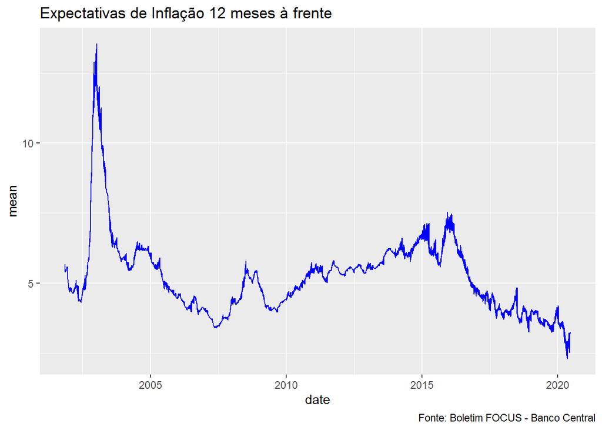

```r
ipcae1=ggplot(expipca, aes(date, mean))+
geom_line(color="blue")+
labs(title='Expectativas de Inflação 12 meses à frente',
caption='Fonte: Boletim FOCUS - Banco Central')
ipcae1
```

E agora da mediana das expectativas:

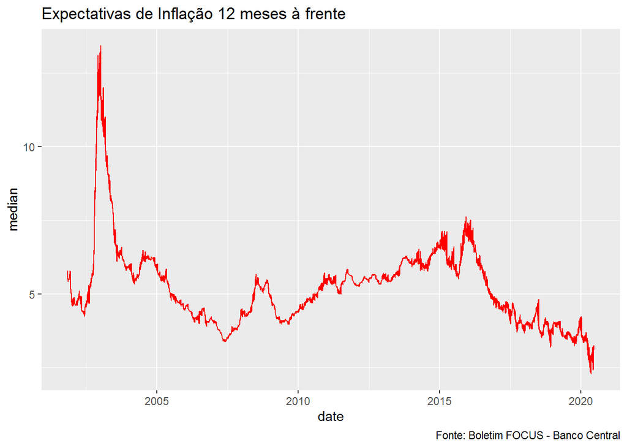

```r
ipcae2=ggplot(expipca, aes(date, median))+
geom_line(color="red")+
labs(title='Expectativas de Inflação 12 meses à frente',
caption='Fonte: Boletim FOCUS - Banco Central')
ipcae2
```

E por fim, do desvio-padrão dessas expectativas, que nos dá uma medida de incerteza.

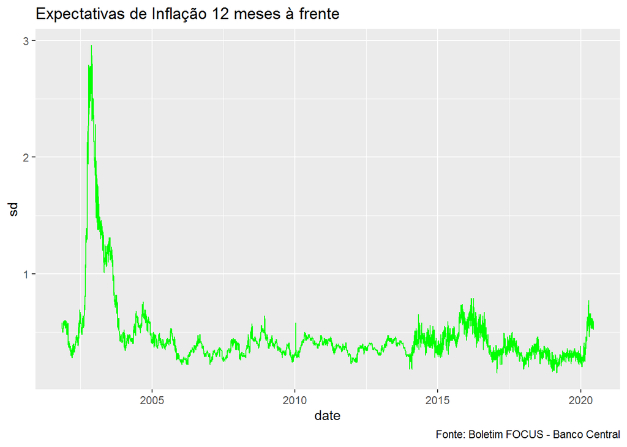

```r
ipcae3=ggplot(expipca, aes(date, sd))+
geom_line(color="green")+
labs(title='Expectativas de Inflação 12 meses à frente',
caption='Fonte: Boletim FOCUS - Banco Central')
ipcae3
```

Usando grid.arrange vamos colocar os 3 gráficos juntos:

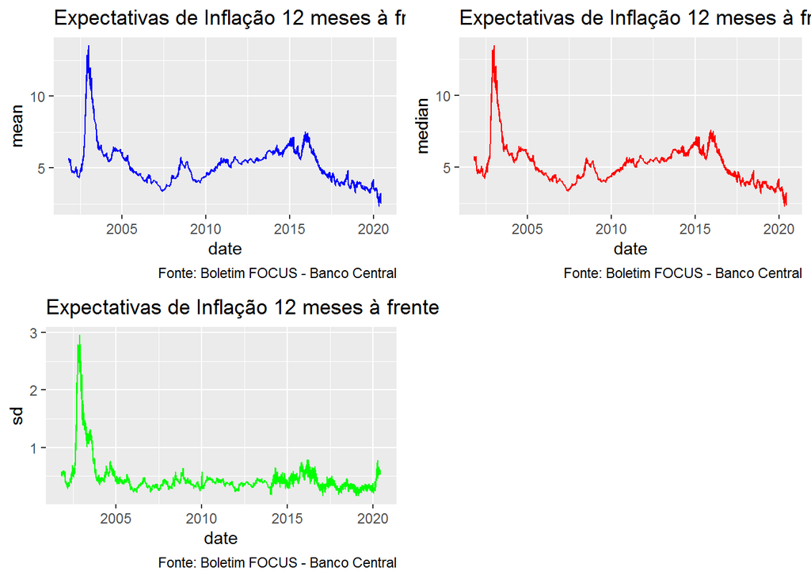

```r
grid.arrange(ipcae1, ipcae2, ipcae3, ncol=2)
```

Vamos olhar agora para as expectativas de crescimento econômico (PIB). Primeiro, faremos um gráfico usando o desvio-padrão (sd). Como vocês podem notar, a incerteza sobre o crescimento do PIB aumentou drasticamente durante a pandemia.

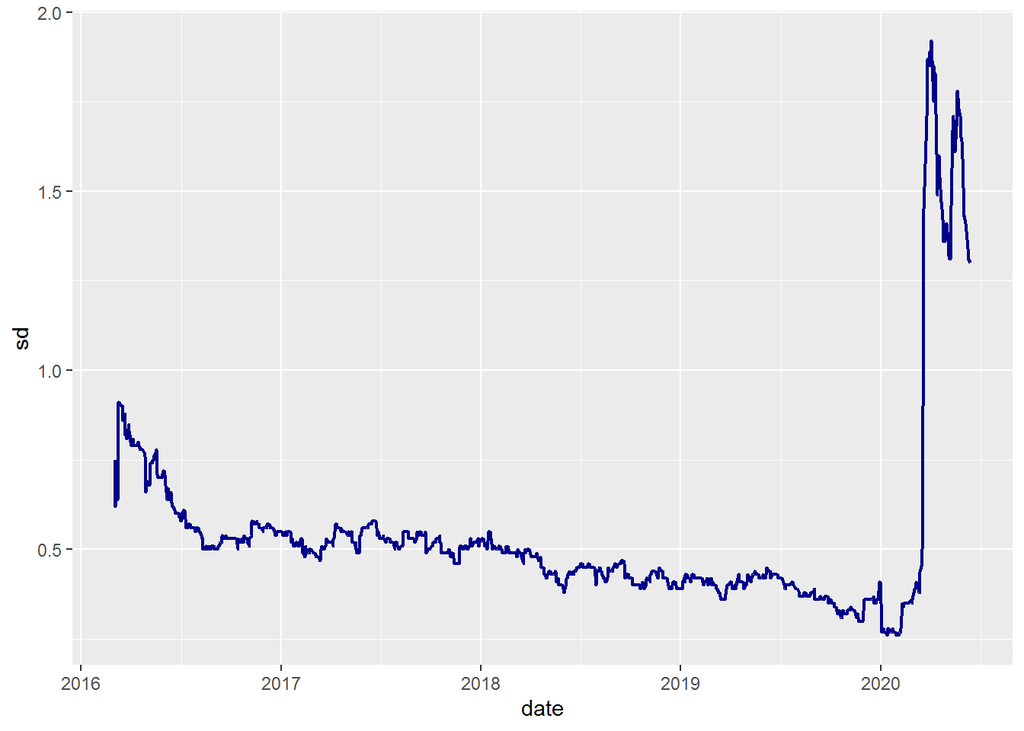

```r
#importa os dados de expectativas para o PIB a partir de 2015).
pibe = get_annual_market_expectations('PIB Total',
start_date = '2015-01-01')

#vamos usar ferramentas que aprendemos anteriormente para filtrar os dados e fazer o gráfico.

filter(pibe, reference_year == 2020 & date > '2016-02-01') %>%
ggplot(aes(x=date))+
geom_line(aes(y=sd), size=.8, color="darkblue")
```

Um outro exemplo abaixo:

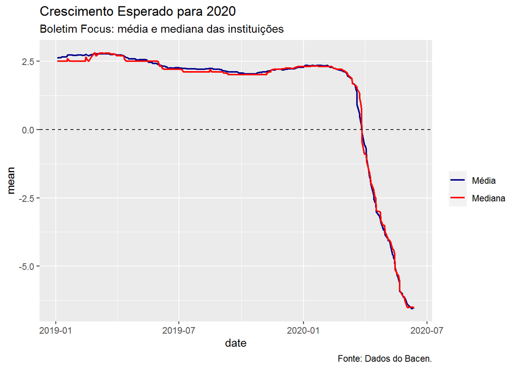

```r
#importa as expectativas de crescimento desde 2017

pibe = get_annual_market_expectations('PIB Total',
start_date = '2017-01-02')

# vamos fazer no mesmo gráfico a média e a mediana das expectativas de crescimento desde 2019.

filter(pibe, reference_year == '2020' & date > '2019-01-02') %>%
ggplot(aes(x=date))+
geom_line(aes(y=mean, colour='Média'), size=.8)+
geom_line(aes(y=median, colour='Mediana'), size=.8)+
scale_colour_manual('', values=c('Média'='darkblue',
'Mediana'='red'))+
geom_hline(yintercept=0, colour='black', linetype='dashed')+
labs(title='Crescimento Esperado para 2020',
subtitle='Boletim Focus: média e mediana das instituições',
caption='Fonte: Dados do Bacen.')
```

Agora faremos 3 gráficos: para as expectativas de crescimento de 2017, 2018 e 2019.

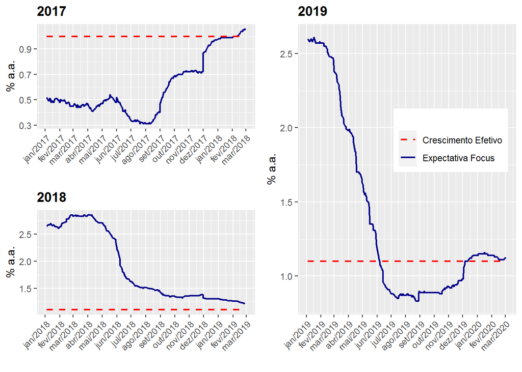

```r
#exemplo adaptado do Blog Análise Macro
#usando dplyr e ggplot vamos pegar as expectativas para os anos de 2017, 2018 e 2019 e calcular o crescimento efetivo
g1 = filter(pibe, reference_year == '2017' & date > '2017-01-03' &
date <= '2018-03-31') %>%
mutate(crescimento_efetivo = rep(1, length(mean))) %>%
ggplot(aes(x=date))+
geom_line(aes(y=mean), size=.8, colour='darkblue')+
geom_line(aes(y=crescimento_efetivo), size=.8, colour='red',
linetype='dashed')+
theme(plot.title = element_text(size=13,
face='bold'))+
scale_x_date(breaks = date_breaks("1 month"),
labels = date_format("%b/%Y"))+
theme(axis.text.x=element_text(angle=45, hjust=1))+
labs(x='', y='% a.a.',
title='2017')

g2 = filter(pibe, reference_year == '2018' & date > '2018-01-03' &
date <= '2019-03-31') %>%
mutate(crescimento_efetivo = rep(1.1, length(mean))) %>%
ggplot(aes(x=date))+
geom_line(aes(y=mean), size=.8, colour='darkblue')+
geom_line(aes(y=crescimento_efetivo), size=.8, colour='red',
linetype='dashed')+
theme(plot.title = element_text(size=13,
face='bold'))+
scale_x_date(breaks = date_breaks("1 month"),
labels = date_format("%b/%Y"))+
theme(axis.text.x=element_text(angle=45, hjust=1))+
labs(x='', y='% a.a.',
title='2018')

g3 = filter(pibe, reference_year == '2019' & date > '2019-01-03' &
date <= '2020-03-31') %>%
mutate(crescimento_efetivo = rep(1.1, length(mean))) %>%
ggplot(aes(x=date))+
geom_line(aes(y=mean, colour='Expectativa Focus',
linetype='Expectativa Focus'), size=.8)+
geom_line(aes(y=crescimento_efetivo, colour='Crescimento Efetivo',
linetype='Crescimento Efetivo'), size=.8)+
scale_colour_manual('',
values=c('Expectativa Focus'='darkblue',
'Crescimento Efetivo'='red'))+
scale_linetype_manual('',
values=c('Expectativa Focus'='solid',
'Crescimento Efetivo'='dashed'))+
theme(legend.position = c(.7,.6),
plot.title = element_text(size=13,
face='bold'))+
scale_x_date(breaks = date_breaks("1 month"),
labels = date_format("%b/%Y"))+
theme(axis.text.x=element_text(angle=45, hjust=1))+
labs(x='', y='% a.a.',
title='2019')

#vamos usar grid.arrange de forma que um gráfico ocupe duas linhas. Veja abaixo.
grid.arrange(g1, g2, g3,
layout_matrix=rbind(c(1,3), c(2,3)),
ncol=2)
```

Gráfico do crescimento esperado para 2020. Infelizmente, as perspectivas não são boas.

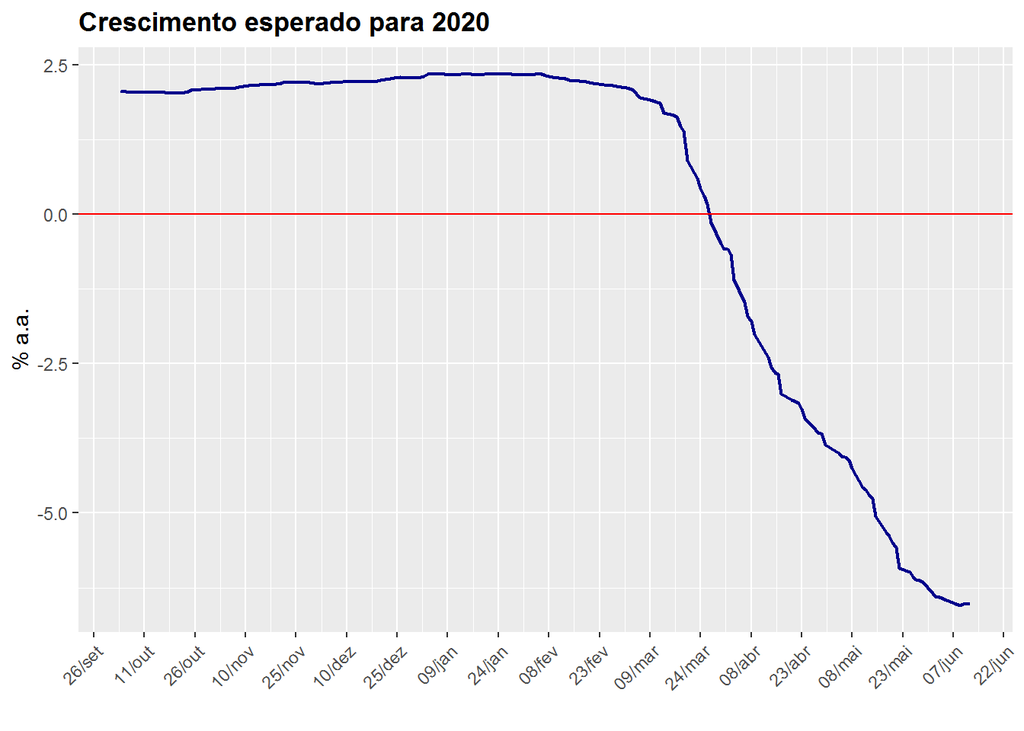

```r
#exemplo adaptado do blog Análise Macro
filter(pibe, reference_year == '2020' & date > '2019-10-03') %>%
ggplot(aes(x=date))+
geom_line(aes(y=mean), size=.8, color = 'darkblue')+
theme(plot.title = element_text(size=13,
face='bold'))+
scale_x_date(breaks = date_breaks("15 days"),
labels = date_format("%d/%b"))+
theme(axis.text.x=element_text(angle=45, hjust=1))+
  geom_hline(yintercept=0, color='red')+
labs(x='', y='% a.a.',
title='Crescimento esperado para 2020')
```

Podemos pegar aqui também os dados do IPCA (série histórica desde 1980).

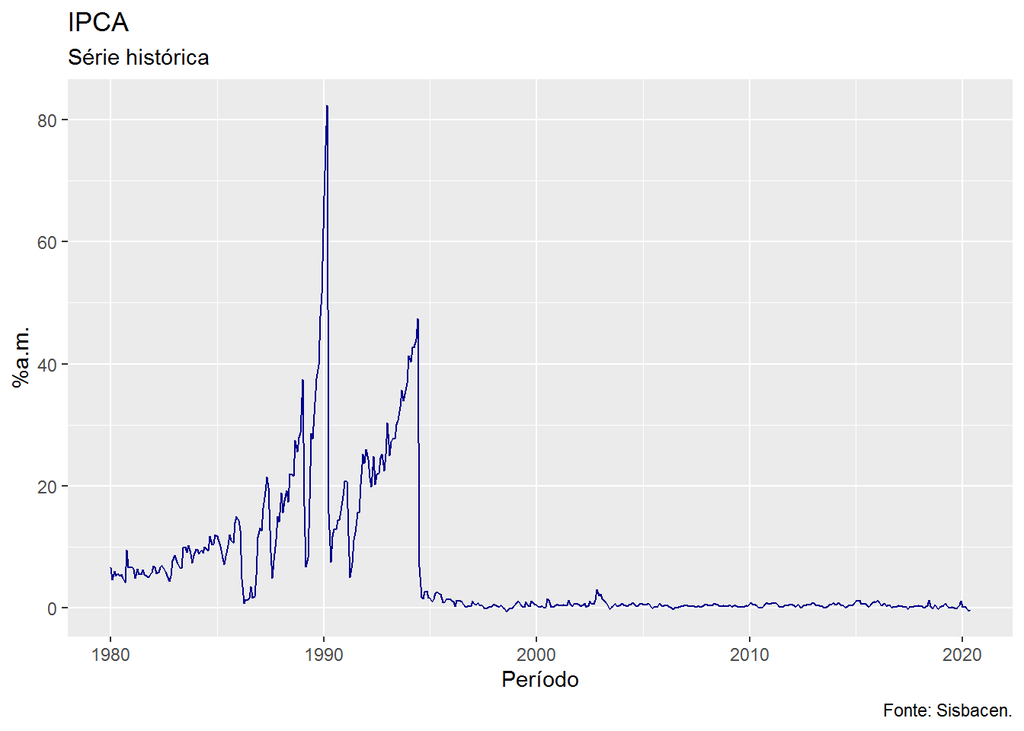

```r
ipca = get_series(433)
ggplot(ipca, aes(x=date))+
  geom_line(aes(y=ipca$`433`), col='darkblue')+
  labs(title='IPCA',
subtitle='Série histórica', x = "Período", y="%a.m.",
caption='Fonte: Sisbacen.')
```

#Agora usando apenas as 40 últimas observações:

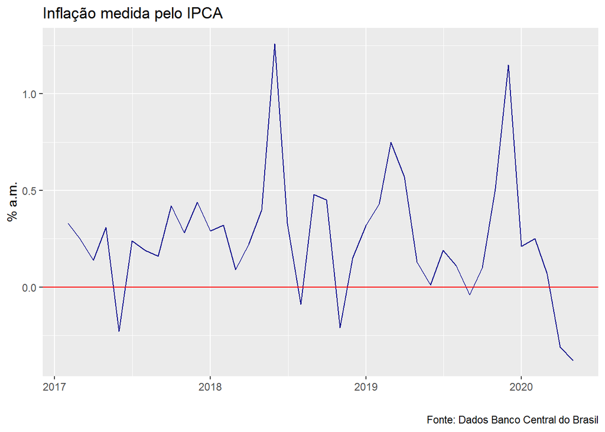

```r
ipca2 = tail(ipca, 40)

ggplot(ipca2, aes(x=date))+
  geom_line(aes(y=ipca2$'433'), col='darkblue')+
  geom_hline(yintercept=0, color='red')+
    labs(x='', y='% a.m.',
title='Inflação medida pelo IPCA', caption="Fonte: Dados Banco Central do Brasil")
```